# Analysis of Comcast telecom complaints

## This notebook answer below questions:

### Q1. Import data into Python environment.

### Q2. Provide the trend chart for the number of complaints at monthly and daily granularity levels.

### Q3. Provide a table with the frequency of complaint types.

### Q4. Which complaint types are maximum i.e., around internet, network issues, or across any other domains.

### Q5. Create a new categorical variable with value as Open and Closed. Open & Pending is to be categorized as Open and Closed & Solved is to be categorized as Closed.

### Q6. Provide state wise status of complaints in a stacked bar chart. Use the categorized variable from above question. Provide insights on:

### Q7. Which state has the maximum complaints

### Q8. Which state has the highest percentage of unresolved complaints

### Q9. Provide the percentage of complaints resolved till date, which were received through the Internet and customer care calls.

#### import necessary libraries

```python
import numpy as np
import pandas as pd
import matplotlib.pyplot as plt
%matplotlib inline
```

### Q1. Import data into Python environment.

```python
df_comcast_complaints = pd.read_csv("Comcast_telecom_complaints_data_old.csv")
```

#### view first 5 rows

```python
df_comcast_complaints.head()
```

|  | Ticket # | Customer Complaint | Date | Date_month_year | Time | Received Via | City | State | Zip code | Status | Filing on Behalf of Someone |
| --- | --- | --- | --- | --- | --- | --- | --- | --- | --- | --- | --- |
| 0 | 250635 | Comcast Cable Internet Speeds | 22-04-15 | 22-Apr-15 | 3:53:50 PM | Customer Care Call | Abingdon | Maryland | 21009 | Closed | No |
| 1 | 223441 | Payment disappear - service got disconnected | 04-08-15 | 04-Aug-15 | 10:22:56 AM | Internet | Acworth | Georgia | 30102 | Closed | No |
| 2 | 242732 | Speed and Service | 18-04-15 | 18-Apr-15 | 9:55:47 AM | Internet | Acworth | Georgia | 30101 | Closed | Yes |
| 3 | 277946 | Comcast Imposed a New Usage Cap of 300GB that ... | 05-07-15 | 05-Jul-15 | 11:59:35 AM | Internet | Acworth | Georgia | 30101 | Open | Yes |
| 4 | 307175 | Comcast not working and no service to boot | 26-05-15 | 26-May-15 | 1:25:26 PM | Internet | Acworth | Georgia | 30101 | Solved | No |

```python
df_comcast_complaints.info()
```

```
<class 'pandas.core.frame.DataFrame'>
RangeIndex: 2224 entries, 0 to 2223
Data columns (total 11 columns):
 #   Column                       Non-Null Count  Dtype
---  ------                       --------------  -----
 0   Ticket #                     2224 non-null   object
 1   Customer Complaint           2224 non-null   object
 2   Date                         2224 non-null   object
 3   Date_month_year              2224 non-null   object
 4   Time                         2224 non-null   object
 5   Received Via                 2224 non-null   object
 6   City                         2224 non-null   object
 7   State                        2224 non-null   object
 8   Zip code                     2224 non-null   int64
 9   Status                       2224 non-null   object
 10  Filing on Behalf of Someone  2224 non-null   object
dtypes: int64(1), object(10)
memory usage: 191.2+ KB
```

```python
#check again if any column has nulls
df_comcast_complaints.isnull().sum()
```

```
Ticket #                       0
Customer Complaint             0
Date                           0
Date_month_year                0
Time                           0
Received Via                   0
City                           0
State                          0
Zip code                       0
Status                         0
Filing on Behalf of Someone    0
dtype: int64
```

#### Convert Date and Time column to new DateTime Column

```python
df_comcast_complaints["DateTime"] = df_comcast_complaints.Date + " " + df_comcast_complaints.Time
df_comcast_complaints["DateTime"] = pd.to_datetime(df_comcast_complaints.DateTime, format="%d-%m-%y %I:%M:%S %p")
df_comcast_complaints["Date_month_year"] = pd.to_datetime(df_comcast_complaints["Date_month_year"])
```

### Q2. (a) Provide the trend chart for the number of complaints at monthly granularity levels.

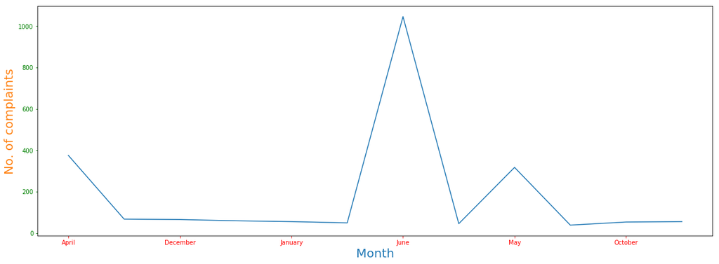

```python
df_comcast_complaints["month"] = pd.to_datetime(df_comcast_complaints["DateTime"]).apply(lambda x: x.strftime('%B'))
ax = df_comcast_complaints.groupby("month").count()["Customer Complaint"].plot(kind = "line", figsize = (20, 7))
ax.set_xlabel("Month",  fontsize=20, color="C0")
ax.set_ylabel("No. of complaints", fontsize=20, color="C1")
ax.tick_params(axis='x', colors='red')
ax.tick_params(axis='y', colors='green')
```

### Q2(b). Provide the trend chart for the number of complaints at daily granularity levels.

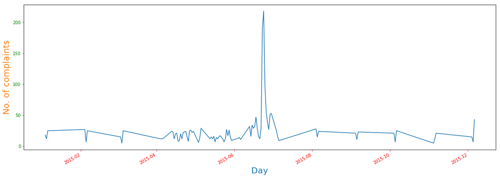

```python
ax = df_comcast_complaints.groupby("Date_month_year").count()["Customer Complaint"].plot(kind = "line", figsize = (20, 7))
ax.set_xlabel("Day",  fontsize=20, color="C0")
ax.set_ylabel("No. of complaints", fontsize=20, color="C1")
ax.tick_params(axis='x', colors='red')
ax.tick_params(axis='y', colors='green')
```

#### Inspect Customer Complaint data

```python
pd.set_option('display.max_rows', 20)
df_comcast_complaints.groupby("Customer Complaint")["Customer Complaint"].size().sort_values(ascending=False)
```

```
Customer Complaint
Comcast                                                                 83
Comcast Internet                                                        18
Comcast Data Cap                                                        17
comcast                                                                 13
Comcast Data Caps                                                       11
                                                                        ..
Lack of availability                                                     1
Lack of communication and poor customer service                          1
Lack of consistent service                                               1
Lack of internet speed                                                   1
(Comcast is not my complaint!) Cyber Tele-marketing is my complaint!     1
Name: Customer Complaint, Length: 1841, dtype: int64
```

#### Let's find out most frequent complaints

```python
# Clean up stop words and punctuations
from nltk.corpus import stopwords
from nltk.stem.wordnet import WordNetLemmatizer
import string

stop = set(stopwords.words('english'))
stop.add("comcast") # let's exclude the company name
exclude = set(string.punctuation + "0123456789")
lemma = WordNetLemmatizer()

def cleanup_text(sentence):
    stop_free = " ".join([i for i in sentence.lower().split() if i not in stop])
    punc_free = "".join([ch for ch in stop_free if ch not in exclude])
    normalised = " ".join(lemma.lemmatize(word) for word in punc_free.split())
    return normalised
```

```python
sentence_total = df_comcast_complaints["Customer Complaint"].tolist()
all_sentence_2_words_list_cleaned = [cleanup_text(word).split() for word in sentence_total]
all_words_cleaned = [item for sublist in all_sentence_2_words_list_cleaned for item in sublist]
df_all_words = pd.DataFrame(all_words_cleaned, index = range(len(all_words_cleaned)), columns=["Complaint Type"])
df_all_words.groupby("Complaint Type").size().sort_values(ascending=False)
```

```
Complaint Type
internet    517
service     496
billing     283
data        219
speed       187
           ...
nightly       1
night         1
nh            1
next          1
loses         1
Length: 1344, dtype: int64
```

### From above we can answer below:

### Q4. Which complaint types are maximum i.e., around internet, network issues, or across any other domains

### A. internet is the highest complained service of Comcast, next is service and the billing, data and speed.

### Q5. Create a new categorical variable with value as Open and Closed. Open & Pending is to be categorized as Open and Closed & Solved is to be categorized as Closed.

```python
#View the Status types and frequency
print(df_comcast_complaints.groupby('Status')["Status"].size())


#Create a function to add new column with new Status
def rename_Status(status):
    if status in ('Open','Pending'):
        return 'Open'
    elif status in ('Closed', 'Solved'):
        return 'Closed'
#Apply the function to Status Column to create newcolumn with new status
df_comcast_complaints["OpenClosed"] = df_comcast_complaints["Status"].apply(rename_Status)

#View the new status type
df_comcast_complaints.groupby("OpenClosed").size()
```

```
Status
Closed     734
Open       363
Pending    154
Solved     973
Name: Status, dtype: int64
```

```
OpenClosed
Closed    1707
Open       517
dtype: int64
```

#### Q6. Provide state wise status of complaints in a stacked bar chart. Use the categorized variable from above question (Q5).

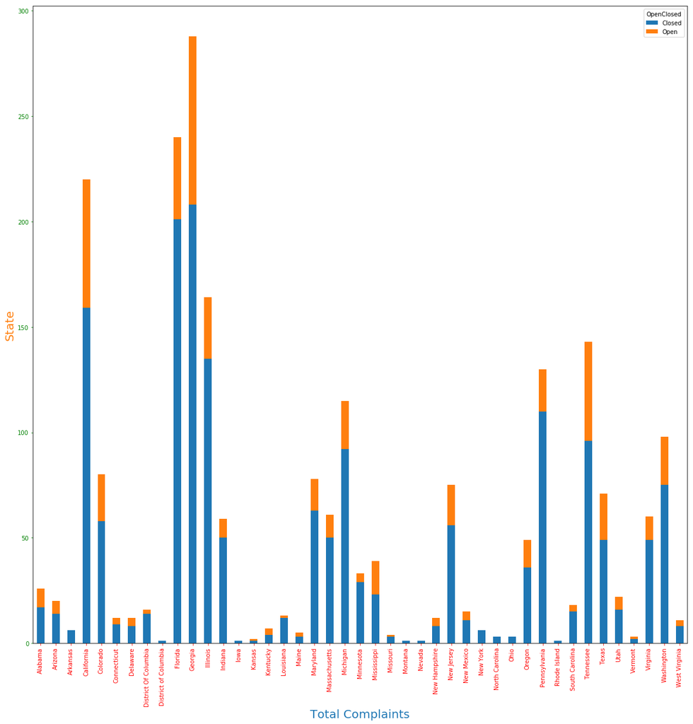

```python
#View the Total complaints by each State using stacked bar chart
ax = df_comcast_complaints.groupby(["State", "OpenClosed"]).size().unstack().plot(kind = "bar",figsize=(20,20), stacked = True)
ax.set_xlabel("Total Complaints",  fontsize=20, color="C0")
ax.set_ylabel("State", fontsize=20, color="C1")
ax.tick_params(axis='x', colors='red')
ax.tick_params(axis='y', colors='green')
```

```python
#Adjust district of columbia as you can observe its repeated twice
df_comcast_complaints["State"].replace({"District of Columbia": "District Of Columbia"}, inplace=True)
```

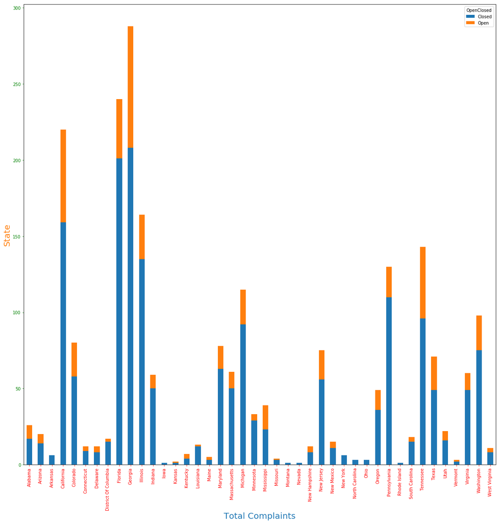

```python
#View the Total complaints by each State using stacked bar chart after adjusting "District of columbia"
ax = df_comcast_complaints.groupby(["State", "OpenClosed"]).size().unstack().plot(kind = "bar",figsize=(20,20), stacked = True)
ax.set_xlabel("Total Complaints",  fontsize=20, color="C0")
ax.set_ylabel("State", fontsize=20, color="C1")
ax.tick_params(axis='x', colors='red')
ax.tick_params(axis='y', colors='green')
```

```python
#View the Total complaints by each State
pd.set_option('display.max_rows', 50)
df_comcast_complaints.groupby("State").size().sort_values(ascending=False).to_frame('Total Complaints')
```

| State | Total Complaints |
| --- | --- |
| Georgia | 288 |
| Florida | 240 |
| California | 220 |
| Illinois | 164 |
| Tennessee | 143 |
| Pennsylvania | 130 |
| Michigan | 115 |
| Washington | 98 |
| Colorado | 80 |
| Maryland | 78 |
| New Jersey | 75 |
| Texas | 71 |
| Massachusetts | 61 |
| Virginia | 60 |
| Indiana | 59 |
| Oregon | 49 |
| Mississippi | 39 |
| Minnesota | 33 |
| Alabama | 26 |
| Utah | 22 |
| Arizona | 20 |
| South Carolina | 18 |
| District Of Columbia | 17 |
| New Mexico | 15 |
| Louisiana | 13 |
| New Hampshire | 12 |
| Connecticut | 12 |
| Delaware | 12 |
| West Virginia | 11 |
| Kentucky | 7 |
| New York | 6 |
| Arkansas | 6 |
| Maine | 5 |
| Missouri | 4 |
| Ohio | 3 |
| Vermont | 3 |
| North Carolina | 3 |
| Kansas | 2 |
| Rhode Island | 1 |
| Montana | 1 |
| Iowa | 1 |
| Nevada | 1 |

#### From above we can answer below

#### Q7: Which state has the maximum complaints

#### A: Georgia state has the highest compaints

#### Q8. Which state has the highest percentage of unresolved complaints

```python
df_comcast_complaints.groupby(["State","OpenClosed"]).size().sort_values(ascending=False).unstack().fillna(0).apply(lambda r: (r/r.sum())*100, axis=1).sort_values("Open",ascending=False)
```

| OpenClosed State | Closed | Open |
| --- | --- | --- |
| Kansas | 50.000000 | 50.000000 |
| Kentucky | 57.142857 | 42.857143 |
| Mississippi | 58.974359 | 41.025641 |
| Maine | 60.000000 | 40.000000 |
| Alabama | 65.384615 | 34.615385 |
| Vermont | 66.666667 | 33.333333 |
| New Hampshire | 66.666667 | 33.333333 |
| Delaware | 66.666667 | 33.333333 |
| Tennessee | 67.132867 | 32.867133 |
| Texas | 69.014085 | 30.985915 |
| Arizona | 70.000000 | 30.000000 |
| Georgia | 72.222222 | 27.777778 |
| California | 72.272727 | 27.727273 |
| Colorado | 72.500000 | 27.500000 |
| West Virginia | 72.727273 | 27.272727 |
| Utah | 72.727273 | 27.272727 |
| New Mexico | 73.333333 | 26.666667 |
| Oregon | 73.469388 | 26.530612 |
| New Jersey | 74.666667 | 25.333333 |
| Missouri | 75.000000 | 25.000000 |
| Connecticut | 75.000000 | 25.000000 |
| Washington | 76.530612 | 23.469388 |
| Michigan | 80.000000 | 20.000000 |
| Maryland | 80.769231 | 19.230769 |
| Virginia | 81.666667 | 18.333333 |
| Massachusetts | 81.967213 | 18.032787 |
| Illinois | 82.317073 | 17.682927 |
| South Carolina | 83.333333 | 16.666667 |
| Florida | 83.750000 | 16.250000 |
| Pennsylvania | 84.615385 | 15.384615 |
| Indiana | 84.745763 | 15.254237 |
| Minnesota | 87.878788 | 12.121212 |
| District Of Columbia | 88.235294 | 11.764706 |
| Louisiana | 92.307692 | 7.692308 |
| Iowa | 100.000000 | 0.000000 |
| Rhode Island | 100.000000 | 0.000000 |
| Ohio | 100.000000 | 0.000000 |
| North Carolina | 100.000000 | 0.000000 |
| New York | 100.000000 | 0.000000 |
| Arkansas | 100.000000 | 0.000000 |
| Nevada | 100.000000 | 0.000000 |
| Montana | 100.000000 | 0.000000 |

```python
pd.set_option('display.max_rows', 5)
```

#### Q8/A: As we can see above "Kansas" has the highest number of unresolved complaints with 50 %

#### Q9. Provide the percentage of complaints resolved till date, which were received through the Internet and customer care calls.

```python
#let's look at all "Received via" column values
df_comcast_complaints.groupby("Received Via").size().to_frame('Total')
```

| Received Via | Total |
| --- | --- |
| Customer Care Call | 1119 |
| Internet | 1105 |

```python
#Lets filter the dataset again with received via Internet and Customer Care Call
df_internet_customercare_complaints_Received_Via = df_comcast_complaints[np.logical_or(df_comcast_complaints["Received Via"] == "Internet", df_comcast_complaints["Received Via"] == "Customer Care Call")]
df_internet_customercare_complaints_Received_Via_Internet = df_comcast_complaints[df_comcast_complaints["Received Via"] == "Internet"]
df_internet_customercare_complaints_Received_Via_Customer_Care_Call = df_comcast_complaints[df_comcast_complaints["Received Via"] == "Customer Care Call"] #
```

```python
df_internet_customercare_complaints_Received_Via_Internet.info()
```

```
<class 'pandas.core.frame.DataFrame'>
Int64Index: 1105 entries, 1 to 2221
Data columns (total 14 columns):
 #   Column                       Non-Null Count  Dtype
---  ------                       --------------  -----
 0   Ticket #                     1105 non-null   object
 1   Customer Complaint           1105 non-null   object
 2   Date                         1105 non-null   object
 3   Date_month_year              1105 non-null   datetime64[ns]
 4   Time                         1105 non-null   object
 5   Received Via                 1105 non-null   object
 6   City                         1105 non-null   object
 7   State                        1105 non-null   object
 8   Zip code                     1105 non-null   int64
 9   Status                       1105 non-null   object
 10  Filing on Behalf of Someone  1105 non-null   object
 11  DateTime                     1105 non-null   datetime64[ns]
 12  month                        1105 non-null   object
 13  OpenClosed                   1105 non-null   object
dtypes: datetime64[ns](2), int64(1), object(11)
memory usage: 129.5+ KB
```

```python
df_internet_customercare_complaints_Received_Via_Customer_Care_Call.info()
```

```
<class 'pandas.core.frame.DataFrame'>
Int64Index: 1119 entries, 0 to 2223
Data columns (total 14 columns):
 #   Column                       Non-Null Count  Dtype
---  ------                       --------------  -----
 0   Ticket #                     1119 non-null   object
 1   Customer Complaint           1119 non-null   object
 2   Date                         1119 non-null   object
 3   Date_month_year              1119 non-null   datetime64[ns]
 4   Time                         1119 non-null   object
 5   Received Via                 1119 non-null   object
 6   City                         1119 non-null   object
 7   State                        1119 non-null   object
 8   Zip code                     1119 non-null   int64
 9   Status                       1119 non-null   object
 10  Filing on Behalf of Someone  1119 non-null   object
 11  DateTime                     1119 non-null   datetime64[ns]
 12  month                        1119 non-null   object
 13  OpenClosed                   1119 non-null   object
dtypes: datetime64[ns](2), int64(1), object(11)
memory usage: 131.1+ KB
```

```python
df_internet_customercare_complaints_Received_Via.groupby(["Received Via","OpenClosed"])["OpenClosed"].size().unstack()
```

| OpenClosed Received Via | Closed | Open |
| --- | --- | --- |
| Customer Care Call | 864 | 255 |
| Internet | 843 | 262 |

```python
df_internet_customercare_complaints_Received_Via.groupby(["Received Via","OpenClosed"])["OpenClosed"].size().unstack().apply(lambda x: 100*x/x.sum(), axis =1)
```

| OpenClosed Received Via | Closed | Open |
| --- | --- | --- |
| Customer Care Call | 77.211796 | 22.788204 |
| Internet | 76.289593 | 23.710407 |

#### From above we can answer below:

#### Q9/A: Total percentage of complaints resolved till date, which were received through the Internet - 76.289593% and customer care calls - 77.211796 % :

# © - July 2020 : Lanka, Nirmal Kumar